# Tratamiento

Max Orozco Carstensen

2023-10-12

Considera el siguiente conjunto de ecuaciones diferenciales que describen una enfermedad infecciosa con individuos en tratamiento $T(t)$.

$$\dot S = \nu - \beta_1 \frac {SI} {N} -
\mu S$$
$$\dot E = \beta_1\frac{SI}{N}
+ \beta_2 \frac{TI}{N}-(\mu +\kappa +r_1)E +pr_2I$$
$$\dot I = \kappa E-(r_2+\mu)I$$
$$\dot T = r_1E +qr_2I -\beta_2\frac{TI}{N}-\mu
T$$

con $N(t)=S(t)+E(t)+I(t)+T(t)$

1. **Dibuja el esquema por compartimentos que representa este conjunto de ecuaciones.**

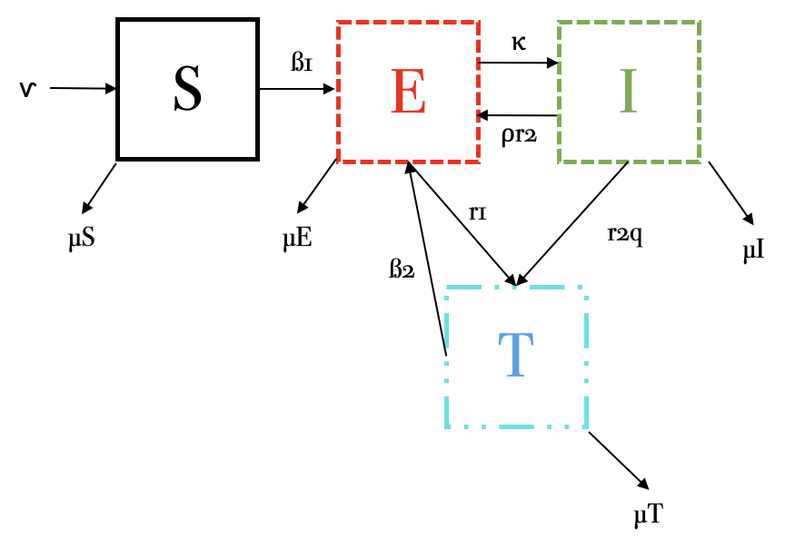

Todas las tasas son acotadas, debido a que es $1/tiempo$. Además, la población y la proporción de la población también es acotada y va de 0 a 1, como si fuera el 100%.

*Susceptibles:*

Favorece:

- $\nu$: Individuos que nacen o entran al sistema.

Afecta:

- $\beta_1 \frac{SI}{N}$: Interacción entre susceptibles e infectados.
- $\mu S$: Individuos susceptibles que mueren o salen del sistema.

*Expuestos:*

Favorece:

- $\beta_1 \frac{SI}{N}$: Interacción entre susceptibles e infectados.
- $\beta_2 \frac{SI}{N}$: Interacción entre tratamiento e infectados.
- $pr_2 I$: Proporción de individuos infectados que pasa a expuestos.

Afecta:

- $\mu E$: Individuos expuestos que mueren o salen del sistema.
- $\kappa E$: Individuos expuestos que pasan a infectados.
- $r_1 E$: Individuos expuestos que pasan a tratamiento.

*Infectados:*

Favorece:

- $\kappa E$: Individuos expuestos que pasan a infectados.

Afecta:

- $r_2 I$: Individuos infectados que pasan a tratamiento.
- $\mu I$: Individuos infectados que mueren o salen del sistema.

*Tratamiento:*

Favorece:

- $r_1 E$: Individuos expuestos que pasan a tratamiento.
- $qr_2 I$: Proporción de individuos infectados que pasan a tratamiento.

Afecta:

- $\beta_2 \frac{SI}{N}$: Interacción entre tratamiento e infectados.
- $\mu T$: Individuos en tratamiento que mueren o salen del sistema.
3. **¿Bajo qué condiciones la población se conservaría?**

La población se conservaría si la suma de las tasas de muerte es igual a la tasa de nacimientos.

$$\nu = (\mu S + \mu E + \mu I + \mu
T)$$

4. **Encuentra, si existe, el punto de equilibrio *free-disease***

Debido a que el modelo *free-disease* hace referencia a que no hay individuos infectados, con esa misma premisa, no puede haber individuos expuestos, únicamente susceptibles y en tratamiento. Si se igualan esas condiciones a 0, queda:

$$\dot S = \nu - \beta_1 \frac {S0} {N} -
\mu S = S = \nu/\mu$$
$$\dot E =
\beta_1\frac{S0}{N} + \beta_2 \frac{T0}{N}-(\mu +\kappa +r_1)0 +pr_20 =
0$$
$$\dot I = \kappa 0-(r_2+\mu)0 =
0$$
$$\dot T = r_10 +qr_20
-\beta_2\frac{T0}{N}-\mu T = T = \mu$$

Por lo tanto, el punto de equilibrio *free-disease* sería: $(S, E, I, T) = (\nu / \mu, 0, 0, \mu)$

5. **¿Qué tipo de enfermedad puede estar describiendo? Justifica tu respuesta.**

VIH, pues se tienen estadios infectivos, expuestos y en tratamiento. Además, sin importar el tipo de tratamiento, siempre habrá posibilidad de que un individuo en tratamiento infecte a otro y entre al estado expuesto. Finalmente, los individuos pueden estar pasando entre expuestos, infectados y en tratamiento.

6. **Selecciona un conjunto de parámetros adecuados y resuelve numéricamente el sistema de ecuaciones diferenciales. Asegúrate que tu solución alcance un punto de equilibrio.Discute tu resultado.**

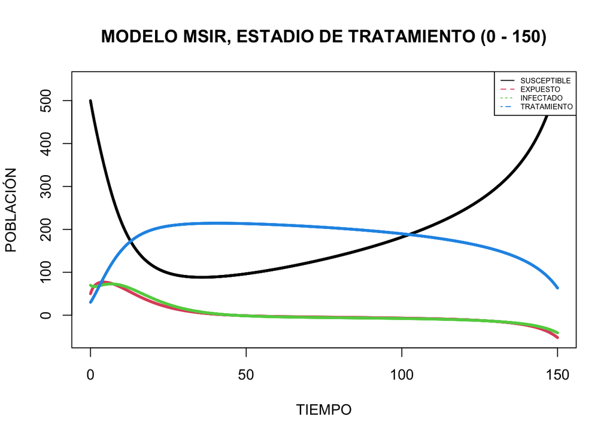

```r
library (deSolve)

SEIT <- function (time, state, parameters) {
  with (as.list (c (state, parameters)), {
    dS <- nu - beta1 * (S * I / N) - muS
    dE <- beta1 * (S * I / N) + beta2 * (Tr * I / N) - kappa * E - r1 * E + p * r2 * I - muE
    dI <- kappa * E - r2 * I - muI
    dT <- r1 * E + q * r2 * I - beta2 * (Tr * I / N) - muT
    list (c (dS, dE, dI, dT))
  })
}

parameters <- c (nu = 1, beta1 = 0.8, beta2 = 0.4, kappa = 0.3, r1 = 0.2, p = 0.2, r2 = 0.3, q = 0.1, muS = 0.2, muE = 0.4, muI = 0.4, muT = 0.1, N = 650)
initial_conditions <- c (S = 500, E = 50, I = 70, Tr = 30)
time <- seq (0, 150, by = 0.001)
out <- ode (initial_conditions, time, SEIT, parameters)

matplot (out [ , 1], out [ , 2 : 5], type = "l", xlab = "TIEMPO", ylab = "POBLACIÓN", main = "MODELO MSIR, ESTADIO DE TRATAMIENTO (0 - 150)", lwd = 3)
legend ("topright", c ("SUSCEPTIBLE", "EXPUESTO", "INFECTADO", "TRATAMIENTO"), col = 1 : 4, lty = 1 : 5, cex = 0.5)
```

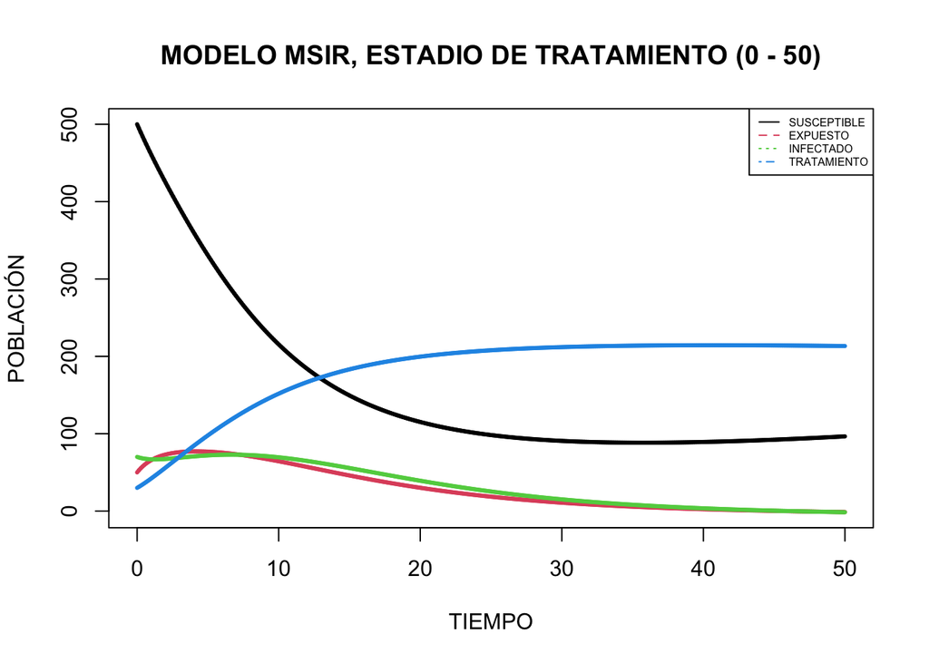

```r
parameters <- c (nu = 1, beta1 = 0.8, beta2 = 0.4, kappa = 0.3, r1 = 0.2, p = 0.2, r2 = 0.3, q = 0.1, muS = 0.2, muE = 0.4, muI = 0.4, muT = 0.1, N = 650)
initial_conditions <- c (S = 500, E = 50, I = 70, Tr = 30)
time <- seq (0, 50, by = 0.001)
out <- ode (initial_conditions, time, SEIT, parameters)

matplot (out [ , 1], out [ , 2 : 5], type = "l", xlab = "TIEMPO", ylab = "POBLACIÓN", main = "MODELO MSIR, ESTADIO DE TRATAMIENTO (0 - 50)", lwd = 3)
legend ("topright", c ("SUSCEPTIBLE", "EXPUESTO", "INFECTADO", "TRATAMIENTO"), col = 1 : 4, lty = 1 : 5, cex = 0.5)
```